## Setup

### Load packages

```r
library(ggplot2)      # library to create plots
library(dplyr)        # data manipulation
library(tidyr)
library(statsr)       # staistics functions
library(BAS)          # Bayesian statistics functions
library(GGally)       # library to create plots
library(knitr)        # required to apply knitr options
library(MASS)         # AIC functions
```

### Load data

```r
load("movies.Rdata")
```

## Part 1: Data

The present data were derived from an observational study. The data set is comprised of 651 randomly sampled movies produced and released from 1970 to 2014. According to IMDb, there have 9,962 movies been release from 1972 to 2016 so that the 10% condition (9,962*10% = 996) is met. Since the sampling size is large enough and less than 10% of population, it can assume that the random sampling is conducted. Therefore we can conclude that the sample is indeed generalizable to the entire population.

```r
# evaluate the size of the dataset
dim(movies)
```

```
## [1] 651  32
```

```r
# verify types and summary of each variable
str(movies)
```

```
## tibble [651 x 32] (S3: tbl_df/tbl/data.frame)
##  $ title           : chr [1:651] "Filly Brown" "The Dish" "Waiting for Guffman" "The Age of Innocence" ...
##  $ title_type      : Factor w/ 3 levels "Documentary",..: 2 2 2 2 2 1 2 2 1 2 ...
##  $ genre           : Factor w/ 11 levels "Action & Adventure",..: 6 6 4 6 7 5 6 6 5 6 ...
##  $ runtime         : num [1:651] 80 101 84 139 90 78 142 93 88 119 ...
##  $ mpaa_rating     : Factor w/ 6 levels "G","NC-17","PG",..: 5 4 5 3 5 6 4 5 6 6 ...
##  $ studio          : Factor w/ 211 levels "20th Century Fox",..: 91 202 167 34 13 163 147 118 88 84 ...
##  $ thtr_rel_year   : num [1:651] 2013 2001 1996 1993 2004 ...
##  $ thtr_rel_month  : num [1:651] 4 3 8 10 9 1 1 11 9 3 ...
##  $ thtr_rel_day    : num [1:651] 19 14 21 1 10 15 1 8 7 2 ...
##  $ dvd_rel_year    : num [1:651] 2013 2001 2001 2001 2005 ...
##  $ dvd_rel_month   : num [1:651] 7 8 8 11 4 4 2 3 1 8 ...
##  $ dvd_rel_day     : num [1:651] 30 28 21 6 19 20 18 2 21 14 ...
##  $ imdb_rating     : num [1:651] 5.5 7.3 7.6 7.2 5.1 7.8 7.2 5.5 7.5 6.6 ...
##  $ imdb_num_votes  : int [1:651] 899 12285 22381 35096 2386 333 5016 2272 880 12496 ...
```

[output cut: 18 more lines]

```r
summary(movies)
```

```
##     title                  title_type                 genre        runtime
##  Length:651         Documentary : 55   Drama             :305   Min.   : 39.0
##  Class :character   Feature Film:591   Comedy            : 87   1st Qu.: 92.0
##  Mode  :character   TV Movie    :  5   Action & Adventure: 65   Median :103.0
##                                        Mystery & Suspense: 59   Mean   :105.8
##                                        Documentary       : 52   3rd Qu.:115.8
##                                        Horror            : 23   Max.   :267.0
##                                        (Other)           : 60   NA's   :1
##   mpaa_rating                               studio    thtr_rel_year
##  G      : 19   Paramount Pictures              : 37   Min.   :1970
##  NC-17  :  2   Warner Bros. Pictures           : 30   1st Qu.:1990
##  PG     :118   Sony Pictures Home Entertainment: 27   Median :2000
##  PG-13  :133   Universal Pictures              : 23   Mean   :1998
##  R      :329   Warner Home Video               : 19   3rd Qu.:2007
##  Unrated: 50   (Other)                         :507   Max.   :2014
##                NA's                            :  8
##  thtr_rel_month   thtr_rel_day    dvd_rel_year  dvd_rel_month
##  Min.   : 1.00   Min.   : 1.00   Min.   :1991   Min.   : 1.000
##  1st Qu.: 4.00   1st Qu.: 7.00   1st Qu.:2001   1st Qu.: 3.000
##  Median : 7.00   Median :15.00   Median :2004   Median : 6.000
##  Mean   : 6.74   Mean   :14.42   Mean   :2004   Mean   : 6.333
##  3rd Qu.:10.00   3rd Qu.:21.00   3rd Qu.:2008   3rd Qu.: 9.000
##  Max.   :12.00   Max.   :31.00   Max.   :2015   Max.   :12.000
##                                  NA's   :8      NA's   :8
##   dvd_rel_day     imdb_rating    imdb_num_votes           critics_rating
##  Min.   : 1.00   Min.   :1.900   Min.   :   180   Certified Fresh:135
##  1st Qu.: 7.00   1st Qu.:5.900   1st Qu.:  4546   Fresh          :209
##  Median :15.00   Median :6.600   Median : 15116   Rotten         :307
##  Mean   :15.01   Mean   :6.493   Mean   : 57533
##  3rd Qu.:23.00   3rd Qu.:7.300   3rd Qu.: 58301
##  Max.   :31.00   Max.   :9.000   Max.   :893008
##  NA's   :8
##  critics_score    audience_rating audience_score  best_pic_nom best_pic_win
##  Min.   :  1.00   Spilled:275     Min.   :11.00   no :629      no :644
##  1st Qu.: 33.00   Upright:376     1st Qu.:46.00   yes: 22      yes:  7
##  Median : 61.00                   Median :65.00
##  Mean   : 57.69                   Mean   :62.36
##  3rd Qu.: 83.00                   3rd Qu.:80.00
##  Max.   :100.00                   Max.   :97.00
##
```

[output cut: 9 more lines]

```
##  Length:651         Length:651         Length:651         Length:651
##  Class :character   Class :character   Class :character   Class :character
##  Mode  :character   Mode  :character   Mode  :character   Mode  :character
##
##
##
##
##     actor5            imdb_url            rt_url
##  Length:651         Length:651         Length:651
##  Class :character   Class :character   Class :character
##  Mode  :character   Mode  :character   Mode  :character
##
##
##
##
```

The data cannot be used to establish a causal relation between the variables of interest as there was no random assignment to the explanatory and independent variables.

## Part 2: Data manipulation

In the original dataset , not all of the required features have been provided, so we will perform some feature engineering to create the required features. For the analysis new features as oscar_season, summer_season, mpaa_rating_R, drama and feature_film. All of them can be derived from existing variables in the dataset.

```r
# reasign yes or no to feature oscar_season, where release month is either  "10", "11", "12"
movies <- movies %>% mutate(oscar_season = as.factor(ifelse(thtr_rel_month %in% c('10', '11', '12'), 'yes', 'no')))

# reasign yes or no to feature summer_season, where release month is either  "6", "7", "8"
movies <- movies %>% mutate(summer_season = as.factor(ifelse(thtr_rel_month %in% c('6', '7', '8'), 'yes', 'no')))

# reasign yes or no to feature mpaa_rating_R, where mpaa_rating is "R"
movies <- movies %>% mutate(mpaa_rating_R = as.factor(ifelse(mpaa_rating == 'R', 'yes', 'no')))

# reasign yes or no to feature drama, where genre is "drama"
movies <- movies %>% mutate(drama = as.factor(ifelse(genre ==  'Drama', 'yes', 'no')))

# reasign yes or no to feature feature_film, where title_type is "Feature Film"
movies<- movies %>% mutate(feature_film = as.factor(ifelse(title_type ==  'Feature Film', 'yes', 'no')))
```

## Part 3: Exploratory data analysis

We will conduct a “exploratory data analysis of the relationship between `audience_score` and the new variables constructed in the previous part.” ### 3.1. `feature_film` vs `audience_score`

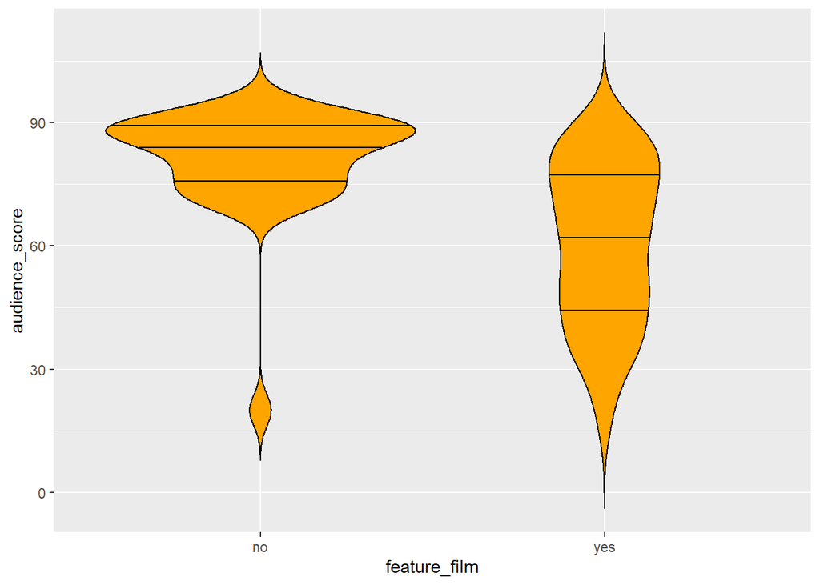

```r
ggplot(data=movies, aes(x=feature_film, y=audience_score))+
  geom_violin(trim = FALSE, draw_quantiles = c(0.25,0.5,0.75),show.legend = TRUE, color='black', fill='orange')
```

Our question here is whether being a feature film. can affect the audience score. The answer is yes. The median of the non-feature film audience score is even higher than the $0.75$ quantile of the feature film movies. We can also see this by summarizing the statistics.

```r
movies%>%group_by(feature_film)%>%summarise(n = n(), median =median(audience_score), mean =mean(audience_score), std = sd(audience_score), SE = sd(audience_score)/sqrt(n()))
```

```
## # A tibble: 2 x 6
##   feature_film     n median  mean   std    SE
##   <fct>        <int>  <dbl> <dbl> <dbl> <dbl>
## 1 no              60   85.5  81.0  13.6 1.75
## 2 yes            591   62    60.5  19.8 0.815
```

Shaping a $95\%$ confidence interval we can roughly say that $CI = \mu\pm1.96\times SE$. Therefore, we can see that $CI_{no}= 81\pm1.96*1.7=(77.67,84.33)$ and $CI_{yes}= 60.5\pm1.96*0.81=(57.17,63.83)$. We can confidently say that these two distributions are not from the same population. We can also perform a hypothesis test, which is not the focus of this section.

### 3.2. `drama` vs `audience_score`

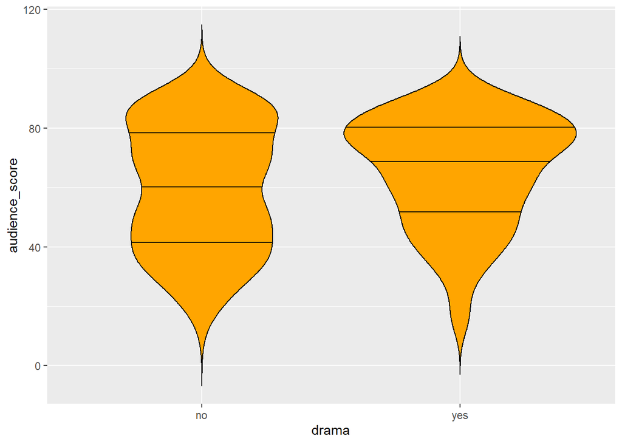

```r
ggplot(data=movies, aes(x=drama, y=audience_score))+
  geom_violin(trim = FALSE, draw_quantiles = c(0.25,0.5,0.75), show.legend = TRUE, color='black', fill='orange')
```

```r
movies%>%group_by(drama)%>%summarise(n = n(), median =median(audience_score), mean =mean(audience_score), std = sd(audience_score), SE = sd(audience_score)/sqrt(n()))
```

```
## # A tibble: 2 x 6
##   drama     n median  mean   std    SE
##   <fct> <int>  <dbl> <dbl> <dbl> <dbl>
## 1 no      346     61  59.7  21.3  1.14
## 2 yes     305     70  65.3  18.5  1.06
```

Shaping a $95\%$ confidence interval we can roughly say that $CI = \mu\pm1.96\times SE$. Therefore, we can see that $CI_{no}= 59.8\pm1.96\times 1.1=(57.64,61.96)$ and $CI_{yes}= 65.3\pm1.96*1.1=(63.14,67.46)$. We can see that the confidence intervals of these two populations are further apart from each other and we can be confident that there is a statistically significant difference here. ### 3.3. `mpaa_rating_R` vs `audience_score`

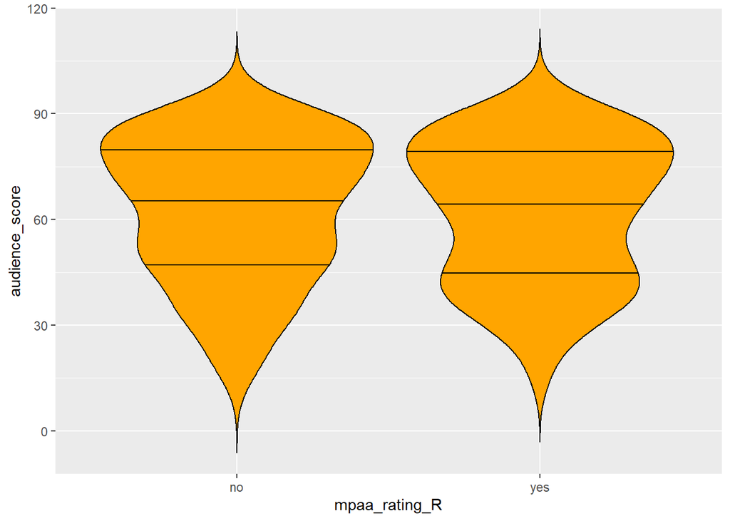

```r
ggplot(data=movies, aes(x=mpaa_rating_R, y=audience_score))+
  geom_violin(trim = FALSE, draw_quantiles = c(0.25,0.5,0.75), show.legend = TRUE, color='black', fill='orange')
```

Shaping a $95\%$ confidence interval we can roughly say that $CI = \mu\pm1.96\times SE$. Therefore, we can see that $CI_{no}= 62.7\pm1.96\times 1.1=(60.54,64.86)$ and $CI_{yes}= 62.0\pm1.96\times1.1=(59.84,64.156)$. We can see that the confidence interval for the mean values of these two groups have a significant overlap. We can confidently say that no variance is explained by this feature. ### 3.4. `oscar/-season` vs `audience_score`

[figure not shown]

```r
ggplot(data=movies, aes(x=oscar_season, y=audience_score))+
  geom_violin(trim = FALSE, draw_quantiles = c(0.25,0.5,0.75), show.legend = TRUE, color='black', fill='orange')
```

#### Visualized EDA

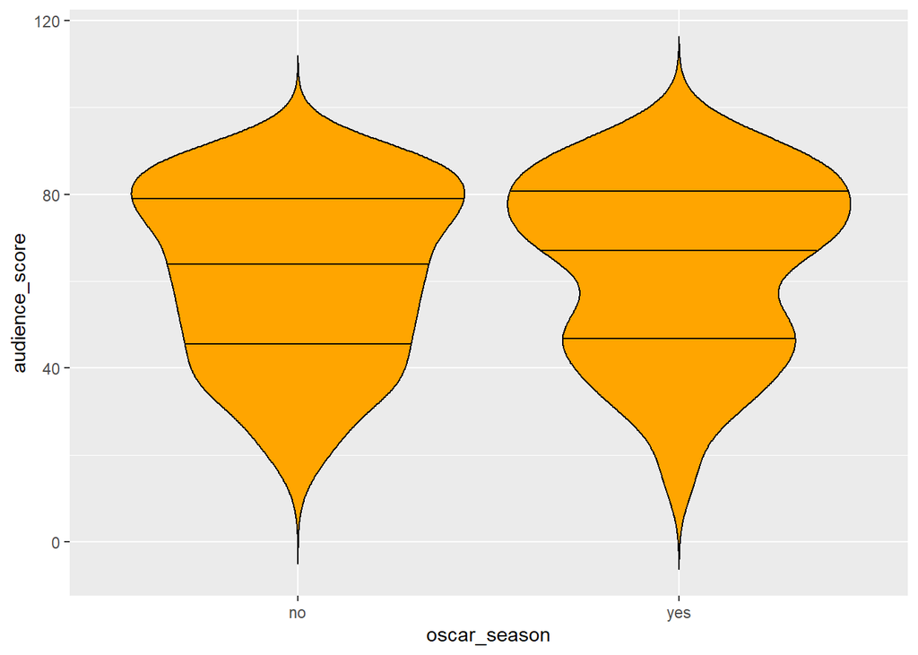

```r
ggplot(data=movies, aes(x=oscar_season, y=audience_score))+
  geom_violin(trim = FALSE, draw_quantiles = c(0.25,0.5,0.75), show.legend = TRUE, color='black', fill='orange')
```

### Summary Statistics EDA

```r
movies%>%group_by(oscar_season)%>%summarise(n = n(), median =median(audience_score), mean =mean(audience_score), std = sd(audience_score), SE = sd(audience_score)/sqrt(n()))
```

```
## # A tibble: 2 x 6
##   oscar_season     n median  mean   std    SE
##   <fct>        <int>  <dbl> <dbl> <dbl> <dbl>
## 1 no             460     64  61.8  20.1 0.938
## 2 yes            191     69  63.7  20.5 1.48
```

### 3.5. `summer_season` vs `audience_score`

#### Visualized EDA

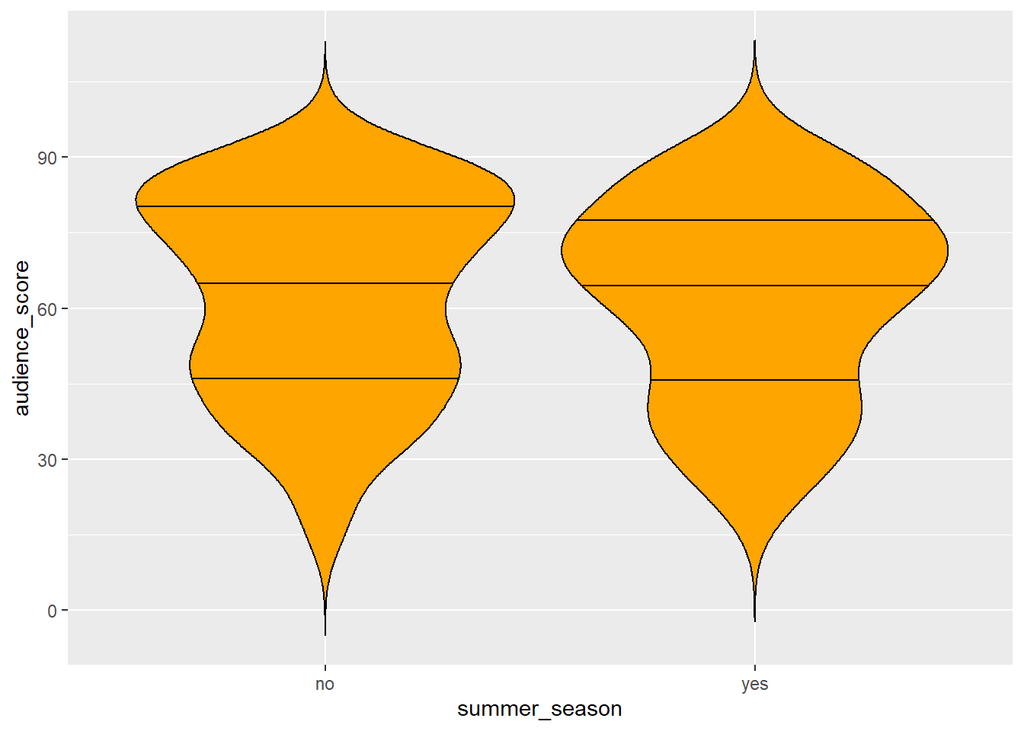

```r
ggplot(data=movies, aes(x=summer_season, y=audience_score))+
  geom_violin(trim = FALSE, draw_quantiles = c(0.25,0.5,0.75), show.legend = TRUE, color='black', fill='orange')
```

Graphically, it seems that there is a small difference between the ratings of movies in summer season and other movies. We can further investigate that using the summary statistics.

#### Summary Statistics EDA

```r
movies%>%group_by(summer_season)%>%summarise(n = n(), median =median(audience_score), mean =mean(audience_score), std = sd(audience_score), SE = sd(audience_score)/sqrt(n()))
```

```
## # A tibble: 2 x 6
##   summer_season     n median  mean   std    SE
##   <fct>         <int>  <dbl> <dbl> <dbl> <dbl>
## 1 no              487     65  62.6  20.4 0.925
## 2 yes             164     65  61.6  19.7 1.54
```

As with the frequentist approach we use these data to perform basic inference on μ the audience_score of all movies in the dataset. To do this we will use the bayes_inference function, which will allow us to construct credible intervals perform a hypothesis test and calculate Bayes factors for a variety of different circumstances. The main goal is to investigate if the newly created features influence the audience_score. Remember we assumed that the new fetures will not influence the audience_score very much.

We will conduct a Bayesian hypothesis test by calculating a Bayes factor for each feature. The following hypothesis is meant to be generic and needs to be adjusted for each individual feature (feature_film, drama, mpaa_rating_R, oscar_season and summer_season). We assigned a uniform prior and use a ‘two sided’ direction for each analysis.

```r
bayes_inference(y = audience_score, data = movies, cred_level = 0.95, statistic = "mean", type = "ci", null = 0)
```

```
## Single numerical variable
## n = 651, y-bar = 62.3625, s = 20.2226
## (Assuming Zellner-Siow Cauchy prior:  mu | sigma^2 ~ C(0, 1*sigma)
## (Assuming improper Jeffreys prior: p(sigma^2) = 1/sigma^2
##
## Posterior Summaries
##            2.5%      25%      50%       75%     97.5%
## mu    60.814869 61.83075 62.36331  62.89334  63.90056
## sigma 19.218234 19.86481 20.25547  20.64035  21.43307
## n_0    3.135671 36.35654 85.53331 171.06906 464.02354
##
## 95% CI for mu: (60.8149, 63.9006)
```

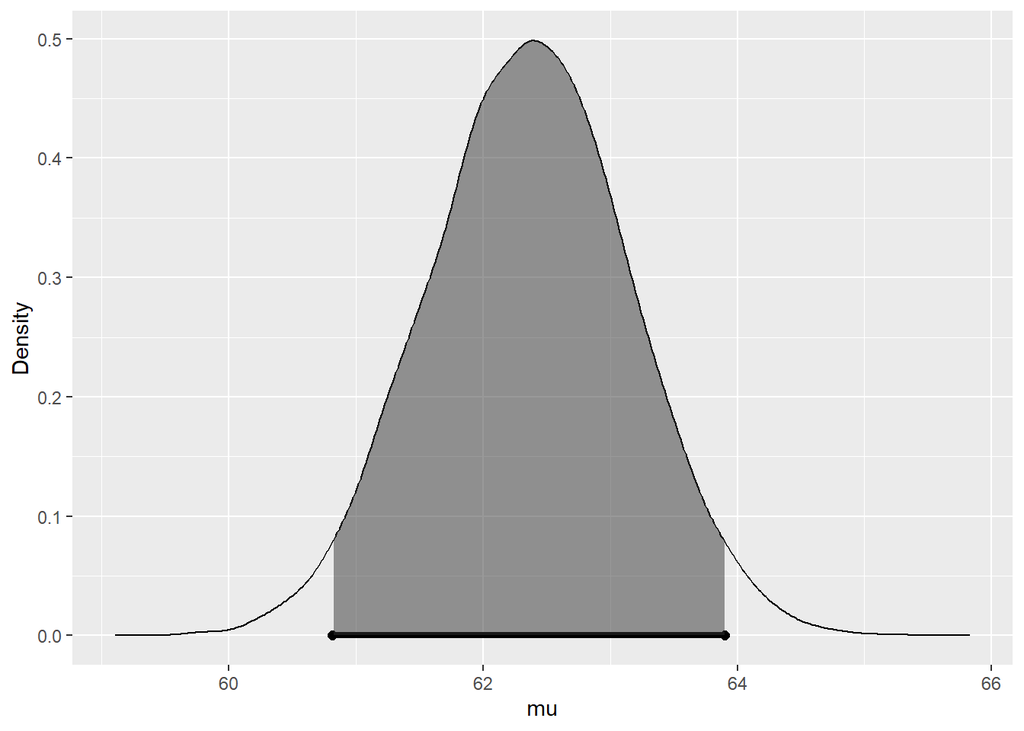

```r
bayes_inference(x = feature_film, y = audience_score, data = movies, cred_level = 0.95, hypothesis_prior = c(0.5, 0.5), statistic = "mean", type = "ht", null = 0, alternative = 'twosided', show_res = TRUE, show_summ = TRUE)
```

```
## Response variable: numerical, Explanatory variable: categorical (2 levels)
## n_no = 60, y_bar_no = 81.05, s_no = 13.5764
## n_yes = 591, y_bar_yes = 60.4653, s_yes = 19.824
## (Assuming Zellner-Siow Cauchy prior on the difference of means. )
## (Assuming independent Jeffreys prior on the overall mean and variance. )
## Hypotheses:
## H1: mu_no  = mu_yes
## H2: mu_no != mu_yes
##
## Priors: P(H1) = 0.5  P(H2) = 0.5
##
## Results:
## BF[H2:H1] = 338337769673
## P(H1|data) = 0
## P(H2|data) = 1
##
## Posterior summaries for under H2:
## Response variable: numerical, Explanatory variable: categorical (2 levels)
## n_no = 60, y_bar_no = 81.05, s_no = 13.5764
## n_yes = 591, y_bar_yes = 60.4653, s_yes = 19.824
## (Assuming Zellner-Siow Cauchy prior for difference in means)
## (Assuming independent Jeffrey's priors for overall mean and variance)
##
##
## Posterior Summaries
##                       2.5%         25%       50%        75%       97.5%
## overall mean    68.0663895  69.7182252  70.57401  71.472748   73.180465
## mu_no - mu_yes  15.1088551  18.4390314  20.18519  21.934885   25.269752
## sigma^2        336.0169748 360.5408691 374.85440 389.513567  418.702433
## effect size      0.7754882   0.9500301   1.04353   1.136472    1.313986
## n_0             16.7169683 182.9257109 431.85383 865.419606 2324.011424
## 95% Cred. Int.: (15.1089 , 25.2698)
```

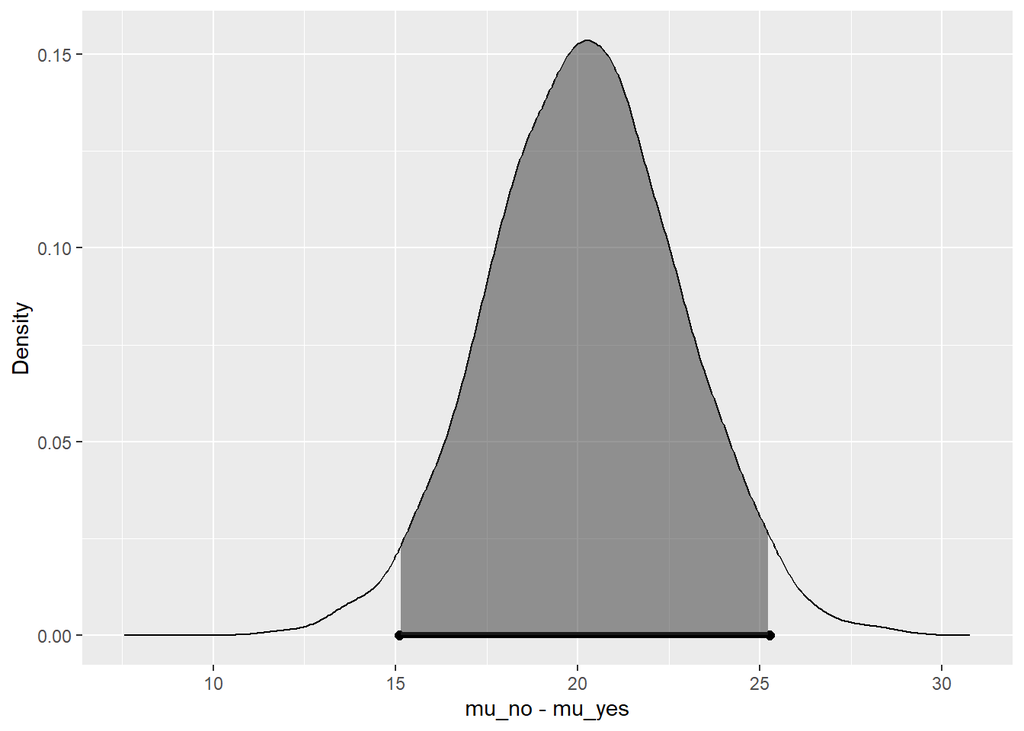

Clearly,with such a large Bayes factor,there is overwhelming evidence against the null hypothesis.Thus being a feature film has a significant effect on audience score.

```r
bayes_inference(x = oscar_season, y = audience_score, data = movies, cred_level = 0.95, hypothesis_prior = c(0.5, 0.5), statistic = "mean", type = "ht", null = 0, alternative = 'twosided', show_res =TRUE, show_summ = TRUE)
```

```
## Response variable: numerical, Explanatory variable: categorical (2 levels)
## n_no = 460, y_bar_no = 61.813, s_no = 20.1196
## n_yes = 191, y_bar_yes = 63.6859, s_yes = 20.4612
## (Assuming Zellner-Siow Cauchy prior on the difference of means. )
## (Assuming independent Jeffreys prior on the overall mean and variance. )
## Hypotheses:
## H1: mu_no  = mu_yes
## H2: mu_no != mu_yes
##
## Priors: P(H1) = 0.5  P(H2) = 0.5
##
## Results:
## BF[H1:H2] = 8.2858
## P(H1|data) = 0.8923
## P(H2|data) = 0.1077
##
## Posterior summaries for under H2:
## Response variable: numerical, Explanatory variable: categorical (2 levels)
## n_no = 460, y_bar_no = 61.813, s_no = 20.1196
## n_yes = 191, y_bar_yes = 63.6859, s_yes = 20.4612
## (Assuming Zellner-Siow Cauchy prior for difference in means)
## (Assuming independent Jeffrey's priors for overall mean and variance)
##
##
## Posterior Summaries
##                       2.5%         25%          50%           75%        97.5%
## overall mean    61.0814672  62.1723352  62.75087077   63.33136155 6.442776e+01
## mu_no - mu_yes  -5.2242621  -3.0248367  -1.87328967   -0.74506441 1.501707e+00
## sigma^2        366.2713629 393.4251692 408.62591141  424.10187343 4.565887e+02
## effect size     -0.2571796  -0.1494652  -0.09227961   -0.03656283 7.433014e-02
## n_0             33.8501366 374.0218892 886.27495029 1795.54611604 4.681472e+03
## 95% Cred. Int.: (-5.2243 , 1.5017)
```

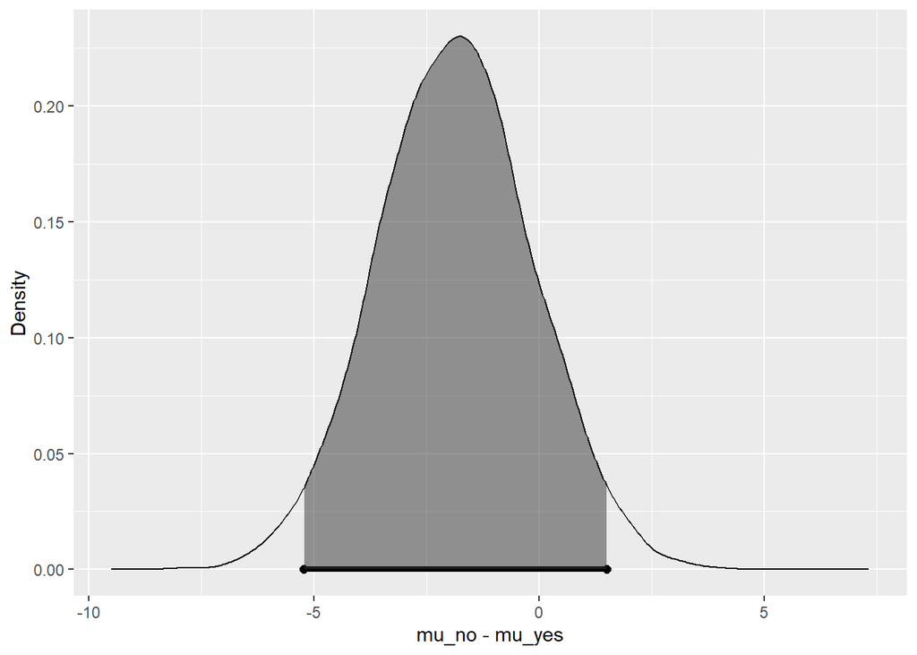

```r
bayes_inference(x = summer_season, y = audience_score, data = movies, cred_level = 0.95, hypothesis_prior = c(0.5, 0.5), statistic = "mean", type = "ht", null = 0, alternative = 'twosided', show_res =TRUE, show_summ =TRUE)
```

```
## Response variable: numerical, Explanatory variable: categorical (2 levels)
## n_no = 487, y_bar_no = 62.6037, s_no = 20.4213
## n_yes = 164, y_bar_yes = 61.6463, s_yes = 19.6646
## (Assuming Zellner-Siow Cauchy prior on the difference of means. )
## (Assuming independent Jeffreys prior on the overall mean and variance. )
## Hypotheses:
## H1: mu_no  = mu_yes
## H2: mu_no != mu_yes
##
## Priors: P(H1) = 0.5  P(H2) = 0.5
##
## Results:
## BF[H1:H2] = 12.222
## P(H1|data) = 0.9244
## P(H2|data) = 0.0756
##
## Posterior summaries for under H2:
## Response variable: numerical, Explanatory variable: categorical (2 levels)
## n_no = 487, y_bar_no = 62.6037, s_no = 20.4213
## n_yes = 164, y_bar_yes = 61.6463, s_yes = 19.6646
## (Assuming Zellner-Siow Cauchy prior for difference in means)
## (Assuming independent Jeffrey's priors for overall mean and variance)
##
##
## Posterior Summaries
##                       2.5%          25%          50%          75%        97.5%
## overall mean    60.3660387  61.50780296  62.12118811   62.7535685   63.9160831
## mu_no - mu_yes  -2.6601137  -0.31236543   0.94106883    2.1539133    4.4132169
## sigma^2        368.8738182 394.39590883 409.56180455  425.1381235  457.6786463
## effect size     -0.1310583  -0.01543683   0.04649488    0.1064376    0.2174148
## n_0             33.4399984 373.86772684 900.00730212 1808.9936422 4751.2424559
## 95% Cred. Int.: (-2.6601 , 4.4132)
```

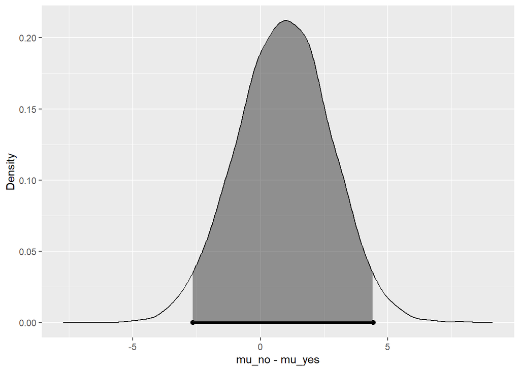

With the Bayes factor about 12,there is positive evidence for H1 and against H2,there is no clear difference between the films released in the summer season and the audience score.

```r
bayes_inference(x = drama, y = audience_score, data = movies, cred_level = 0.95, hypothesis_prior = c(0.5, 0.5), statistic = "mean", type = "ht", null = 0, alternative = 'twosided', show_res = TRUE, show_summ =TRUE)
```

```
## Response variable: numerical, Explanatory variable: categorical (2 levels)
## n_no = 346, y_bar_no = 59.7312, s_no = 21.2775
## n_yes = 305, y_bar_yes = 65.3475, s_yes = 18.5418
## (Assuming Zellner-Siow Cauchy prior on the difference of means. )
## (Assuming independent Jeffreys prior on the overall mean and variance. )
## Hypotheses:
## H1: mu_no  = mu_yes
## H2: mu_no != mu_yes
##
## Priors: P(H1) = 0.5  P(H2) = 0.5
##
## Results:
## BF[H2:H1] = 31.9101
## P(H1|data) = 0.0304
## P(H2|data) = 0.9696
##
## Posterior summaries for under H2:
## Response variable: numerical, Explanatory variable: categorical (2 levels)
## n_no = 346, y_bar_no = 59.7312, s_no = 21.2775
## n_yes = 305, y_bar_yes = 65.3475, s_yes = 18.5418
## (Assuming Zellner-Siow Cauchy prior for difference in means)
## (Assuming independent Jeffrey's priors for overall mean and variance)
##
##
## Posterior Summaries
##                       2.5%         25%         50%          75%        97.5%
## overall mean    60.9847043  61.9920817  62.5206145   63.0546413   64.0932928
## mu_no - mu_yes  -8.6643114  -6.6329212  -5.5706991   -4.4878553   -2.4647789
## sigma^2        360.8951432 386.9005903 401.2381312  417.0078806  448.4542373
## effect size     -0.4321993  -0.3310266  -0.2791511   -0.2235049   -0.1224265
## n_0             32.2107588 350.6897529 841.7941459 1680.1569671 4480.2124007
## 95% Cred. Int.: (-8.6643 , -2.4648)
```

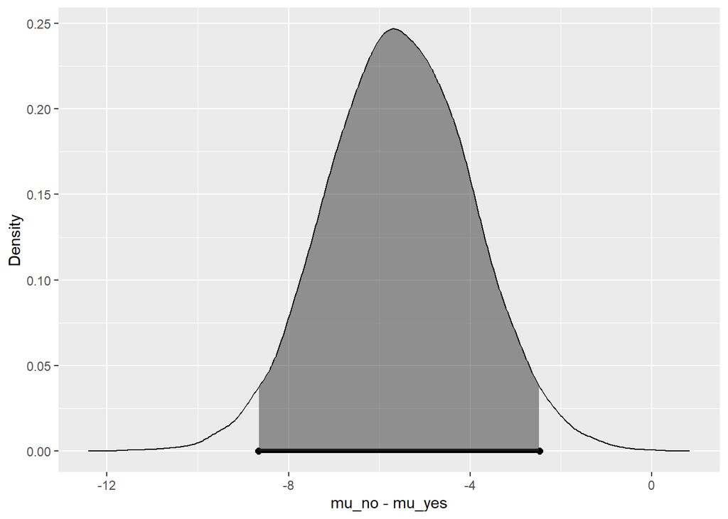

There is strong evidence against H1 and for H2 with a Bayes factor of 32.Thus being a drama film has a significant effect on audience score.

```r
bayes_inference(x = mpaa_rating_R, y = audience_score, data = movies, cred_level = 0.95, hypothesis_prior = c(0.5, 0.5), statistic = "mean", type = "ht", null = 0, alternative = 'twosided', show_res =TRUE, show_summ =TRUE)
```

```
## Response variable: numerical, Explanatory variable: categorical (2 levels)
## n_no = 322, y_bar_no = 62.6894, s_no = 20.3167
## n_yes = 329, y_bar_yes = 62.0426, s_yes = 20.1559
## (Assuming Zellner-Siow Cauchy prior on the difference of means. )
## (Assuming independent Jeffreys prior on the overall mean and variance. )
## Hypotheses:
## H1: mu_no  = mu_yes
## H2: mu_no != mu_yes
##
## Priors: P(H1) = 0.5  P(H2) = 0.5
##
## Results:
## BF[H1:H2] = 14.8147
## P(H1|data) = 0.9368
## P(H2|data) = 0.0632
##
## Posterior summaries for under H2:
## Response variable: numerical, Explanatory variable: categorical (2 levels)
## n_no = 322, y_bar_no = 62.6894, s_no = 20.3167
## n_yes = 329, y_bar_yes = 62.0426, s_yes = 20.1559
## (Assuming Zellner-Siow Cauchy prior for difference in means)
## (Assuming independent Jeffrey's priors for overall mean and variance)
##
##
## Posterior Summaries
##                      2.5%          25%          50%          75%        97.5%
## overall mean    60.860282  61.85761867  62.37424675 6.288501e+01   63.9285319
## mu_no - mu_yes  -2.439171  -0.44918107   0.65312996 1.693458e+00    3.7569317
## sigma^2        368.155823 394.50072501 409.42545623 4.250652e+02  458.5468061
## effect size     -0.120475  -0.02208685   0.03210947 8.357981e-02    0.1856901
## n_0             29.229597 372.65516606 892.37860068 1.798303e+03 4698.0711829
## 95% Cred. Int.: (-2.4392 , 3.7569)
```

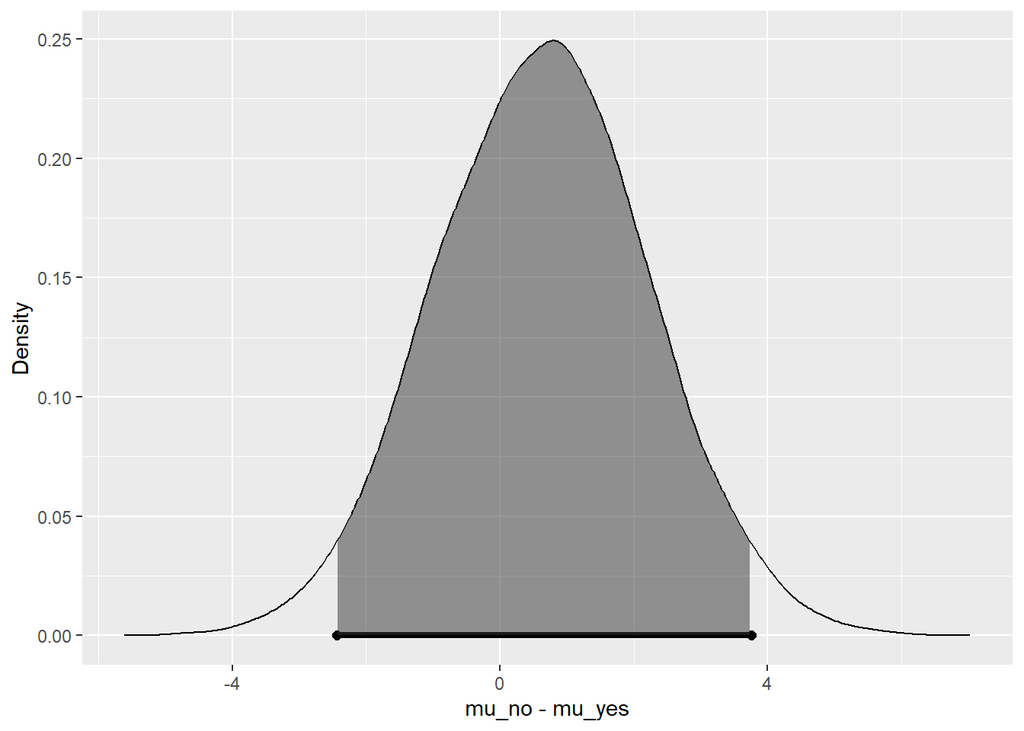

With a Bayes factor of approximately 15,there is positive evidence of H1 and against H2.Thus there is no difference whether the film is mpaa rated or not on audience score.

## Part 4: Modeling

We are going to “Develop a Bayesian regression model to predict audience_score from the following explanatory variables. Note that some of these variables are in the original dataset provided, and others are new variables constructed earlier:”

-`feature_film`

-`drama`

-`runtime`

-`mpaa_rating_R`

-`thtr_rel_year`

-`oscar_season`

-`summer_season`

-`imdb_rating`

-`imdb_num_votes`

-`critics_score`

-`best_pic_nom`

-`best_pic_win`

-`best_actor_win`

-`best_actress_win`

-`best_dir_win`

-`top200_box`

```r
features_to_keep = c("feature_film","drama", "runtime", "mpaa_rating_R", "thtr_rel_year","oscar_season", "summer_season","imdb_rating", "imdb_num_votes","critics_score", "best_pic_win", "best_actor_win", "best_actress_win","best_dir_win", "top200_box", "audience_score")
new_movies <- movies%>%dplyr::select(one_of(features_to_keep))%>%na.omit()
```

Next we are going to generate the basic model that considers all of the mentioned features. Then, we need are going to make sure our model is accurate.

```r
m_movies_full <- lm(audience_score ~ ., data=new_movies)
summary(m_movies_full)
```

```
##
## Call:
## lm(formula = audience_score ~ ., data = new_movies)
##
## Residuals:
##     Min      1Q  Median      3Q     Max
## -28.040  -6.328   0.235   5.680  53.070
##
## Coefficients:
##                       Estimate Std. Error t value Pr(>|t|)
## (Intercept)          1.275e+02  7.771e+01   1.640  0.10148
## feature_filmyes     -1.978e+00  1.688e+00  -1.172  0.24168
## dramayes             1.280e+00  8.770e-01   1.460  0.14491
## runtime             -5.258e-02  2.418e-02  -2.174  0.03004 *
## mpaa_rating_Ryes    -1.513e+00  8.147e-01  -1.857  0.06382 .
## thtr_rel_year       -7.832e-02  3.845e-02  -2.037  0.04210 *
## oscar_seasonyes     -7.046e-01  9.611e-01  -0.733  0.46374
## summer_seasonyes     5.520e-02  9.865e-01   0.056  0.95539
## imdb_rating          1.471e+01  6.073e-01  24.218  < 2e-16 ***
## imdb_num_votes       8.524e-06  4.494e-06   1.897  0.05833 .
## critics_score        6.239e-02  2.210e-02   2.823  0.00491 **
## best_pic_winyes      4.784e-01  4.240e+00   0.113  0.91021
## best_actor_winyes   -1.340e+00  1.179e+00  -1.137  0.25602
## best_actress_winyes -1.928e+00  1.302e+00  -1.481  0.13901
## best_dir_winyes     -1.420e+00  1.734e+00  -0.819  0.41312
## top200_boxyes        7.572e-01  2.787e+00   0.272  0.78591
## ---
## Signif. codes:  0 '***' 0.001 '**' 0.01 '*' 0.05 '.' 0.1 ' ' 1
##
## Residual standard error: 10.01 on 634 degrees of freedom
## Multiple R-squared:  0.7611, Adjusted R-squared:  0.7554
## F-statistic: 134.7 on 15 and 634 DF,  p-value: < 2.2e-16
```

Looking at the frequentist significance of features (p-value) we can conclude that many of the featuers are not significant. Instead of using frequentist adjusted $R^2$, we are going to use the Bayesian BIC criterion for model selection. “BIC (Bayesian Information Criterion) is based on the model fit, while penalizing feature numbers” (similar to adjusted $R^2$". Let’s calculate the BIC for the full model

```r
BIC (m_movies_full)
```

```
## [1] 4932.75
```

I will write a for loop to go through all the independent variables and output a variable that its drop will generate highest decrease in the BIC.

```r
ind_var = c("feature_film","drama", "runtime", "mpaa_rating_R", "thtr_rel_year","oscar_season", "summer_season","imdb_rating", "imdb_num_votes","critics_score", "best_pic_win", "best_actor_win", "best_actress_win","best_dir_win", "top200_box")
for (var in ind_var){
    formula = as.formula(paste("audience_score",paste(var), sep = " ~ . -"))
  model_arr = lm(formula, data = new_movies)
  print(c(var, BIC(model_arr)))
}
```

```
## [1] "feature_film"     "4927.67978788527"
## [1] "drama"            "4928.45364794159"
## [1] "runtime"          "4931.10285874854"
## [1] "mpaa_rating_R"    "4929.79788021296"
## [1] "thtr_rel_year"    "4930.51225907493"
## [1] "oscar_season"    "4926.8241399808"
## [1] "summer_season"    "4926.27652585517"
## [1] "imdb_rating"      "5351.99961740775"
## [1] "imdb_num_votes"   "4929.95079912386"
## [1] "critics_score"    "4934.39222007226"
## [1] "best_pic_win"    "4926.2863642402"
## [1] "best_actor_win"   "4927.59709096599"
## [1] "best_actress_win" "4928.51924503994"
## [1] "best_dir_win"     "4926.96056423093"
## [1] "top200_box"       "4926.34901721468"
```

Our full model’s BIC was 4932.75. Dropping `summer_season` from the model results in $BIC= 4926.276$ which shows the highest increase in the model parsimony.

Let’s see if we can further decrease the BIC.

```r
ind_var_stp1 <- setdiff (ind_var, "summer_season")
for (var in ind_var_stp1){
    formula = as.formula(paste("audience_score",paste(var), sep = " ~ . -"))
  model_arr = lm(formula, data = new_movies)
  print(c(var, BIC(model_arr)))
}
```

```
## [1] "feature_film"     "4927.67978788527"
## [1] "drama"            "4928.45364794159"
## [1] "runtime"          "4931.10285874854"
## [1] "mpaa_rating_R"    "4929.79788021296"
## [1] "thtr_rel_year"    "4930.51225907493"
## [1] "oscar_season"    "4926.8241399808"
## [1] "imdb_rating"      "5351.99961740775"
## [1] "imdb_num_votes"   "4929.95079912386"
## [1] "critics_score"    "4934.39222007226"
## [1] "best_pic_win"    "4926.2863642402"
## [1] "best_actor_win"   "4927.59709096599"
## [1] "best_actress_win" "4928.51924503994"
## [1] "best_dir_win"     "4926.96056423093"
## [1] "top200_box"       "4926.34901721468"
```

```r
model.lm<- lm(audience_score ~ ., data=new_movies)
model.bic <- stepAIC(model.lm,direction='both',k=log(nrow(new_movies)), trace=TRUE)
```

```
## Start:  AIC=3081.65
## audience_score ~ feature_film + drama + runtime + mpaa_rating_R +
##     thtr_rel_year + oscar_season + summer_season + imdb_rating +
##     imdb_num_votes + critics_score + best_pic_win + best_actor_win +
##     best_actress_win + best_dir_win + top200_box
##
##                    Df Sum of Sq    RSS    AIC
## - summer_season     1         0  63484 3075.2
## - best_pic_win      1         1  63485 3075.2
## - top200_box        1         7  63491 3075.3
## - oscar_season      1        54  63538 3075.7
## - best_dir_win      1        67  63551 3075.9
## - best_actor_win    1       129  63613 3076.5
## - feature_film      1       138  63622 3076.6
## - drama             1       213  63697 3077.4
## - best_actress_win  1       220  63704 3077.4
## - mpaa_rating_R     1       345  63829 3078.7
## - imdb_num_votes    1       360  63844 3078.9
## - thtr_rel_year     1       415  63899 3079.4
## - runtime           1       473  63958 3080.0
## <none>                           63484 3081.7
## - critics_score     1       798  64282 3083.3
## - imdb_rating       1     58727 122211 3500.9
##
## Step:  AIC=3075.18
## audience_score ~ feature_film + drama + runtime + mpaa_rating_R +
##     thtr_rel_year + oscar_season + imdb_rating + imdb_num_votes +
##     critics_score + best_pic_win + best_actor_win + best_actress_win +
##     best_dir_win + top200_box
##
##                    Df Sum of Sq    RSS    AIC
## - best_pic_win      1         1  63486 3068.7
## - top200_box        1         7  63492 3068.8
## - oscar_season      1        66  63550 3069.4
## - best_dir_win      1        67  63551 3069.4
## - best_actor_win    1       131  63616 3070.0
## - feature_film      1       137  63622 3070.1
## - drama             1       213  63697 3070.9
## - best_actress_win  1       219  63704 3070.9
## - mpaa_rating_R     1       345  63830 3072.2
```

[output cut: 238 more lines]

```
## - runtime           1       653  65779 3020.5
## + mpaa_rating_R     1       361  64765 3023.4
## - critics_score     1      1073  66199 3024.7
## + thtr_rel_year     1       196  64930 3025.0
## + best_actress_win  1       193  64932 3025.1
## + best_actor_win    1       178  64948 3025.2
## + imdb_num_votes    1       139  64987 3025.6
## + oscar_season      1        82  65044 3026.2
## + top200_box        1        71  65055 3026.3
## + best_dir_win      1        62  65064 3026.4
## + feature_film      1        49  65077 3026.5
## + drama             1        30  65096 3026.7
## + summer_season     1        12  65113 3026.9
## + best_pic_win      1         6  65120 3026.9
## - imdb_rating       1     67874 133000 3478.2
```

```r
#k = log(n) is sometimes referred to as BIC or SBC
```

Looking at the trace from the final model, we see that the model with the best BIC is `audience_score ~ runtime + imdb_rating + critics_score`. If you want to take a look at the trace of model selection, only assign `TRUE` to `trace` in the `stepAIC`` function.

```r
best_model <- lm (audience_score ~ runtime + imdb_rating + critics_score, data = new_movies)
```

This is one single model, which is better than others. However, it doesnt necessary capture all the available information. We will ensemble this model with other models using Bayesian Model Averaging, or BMA. ### 4.1. Bayesian Model Averaging

```r
bma_movies = bas.lm (audience_score ~ ., data=new_movies, prior = "BIC", modelprior =uniform())
summary(bma_movies)
```

```
##                     P(B != 0 | Y)    model 1       model 2       model 3
## Intercept              1.00000000     1.0000     1.0000000     1.0000000
## feature_filmyes        0.06389903     0.0000     0.0000000     0.0000000
## dramayes               0.04299076     0.0000     0.0000000     0.0000000
## runtime                0.44710381     1.0000     0.0000000     0.0000000
## mpaa_rating_Ryes       0.20066511     0.0000     0.0000000     0.0000000
## thtr_rel_year          0.09003490     0.0000     0.0000000     0.0000000
## oscar_seasonyes        0.07525031     0.0000     0.0000000     0.0000000
## summer_seasonyes       0.04069689     0.0000     0.0000000     0.0000000
## imdb_rating            1.00000000     1.0000     1.0000000     1.0000000
## imdb_num_votes         0.05946835     0.0000     0.0000000     0.0000000
## critics_score          0.89682324     1.0000     1.0000000     1.0000000
## best_pic_winyes        0.03879522     0.0000     0.0000000     0.0000000
## best_actor_winyes      0.14264566     0.0000     0.0000000     1.0000000
## best_actress_winyes    0.13550502     0.0000     0.0000000     0.0000000
## best_dir_winyes        0.06639970     0.0000     0.0000000     0.0000000
## top200_boxyes          0.04771958     0.0000     0.0000000     0.0000000
## BF                             NA     1.0000     0.9968489     0.2543185
## PostProbs                      NA     0.1555     0.1550000     0.0395000
## R2                             NA     0.7549     0.7525000     0.7539000
## dim                            NA     4.0000     3.0000000     4.0000000
## logmarg                        NA -3615.2791 -3615.2822108 -3616.6482224
##                           model 4       model 5
## Intercept               1.0000000     1.0000000
## feature_filmyes         0.0000000     0.0000000
## dramayes                0.0000000     0.0000000
## runtime                 0.0000000     1.0000000
## mpaa_rating_Ryes        1.0000000     1.0000000
## thtr_rel_year           0.0000000     0.0000000
## oscar_seasonyes         0.0000000     0.0000000
## summer_seasonyes        0.0000000     0.0000000
## imdb_rating             1.0000000     1.0000000
## imdb_num_votes          0.0000000     0.0000000
## critics_score           1.0000000     1.0000000
## best_pic_winyes         0.0000000     0.0000000
## best_actor_winyes       0.0000000     0.0000000
## best_actress_winyes     0.0000000     0.0000000
## best_dir_winyes         0.0000000     0.0000000
## top200_boxyes           0.0000000     0.0000000
## BF                      0.2521327     0.2391994
## PostProbs               0.0392000     0.0372000
## R2                      0.7539000     0.7563000
## dim                     4.0000000     5.0000000
## logmarg             -3616.6568544 -3616.7095127
```

The results can be quite detailed. It first mentios the posterior nclusion probablity of each feature. We can see that four features have the posterior probablity of not being zero more than 0.2. These are runtime, mpaa_ratin_R, imdb_rating, critics_score. As we also found using our BIC analysis, our first model is the best model. Notice that the posterior probablity is very low even for the best model. You should note that the model prior probablity for each model considering 15 variables (resulting in $2^{15}$ possibilities) is $p = 1/2^{15} =3*10^{-5}$. Therefore, reaching a posterior from such prior with only 650 records demonstrates that the model is reliable.

We can also briefly take a look at the posterior probablity of the dominant features and $95\%$ credible interval for the coeffcients of the averaged model.

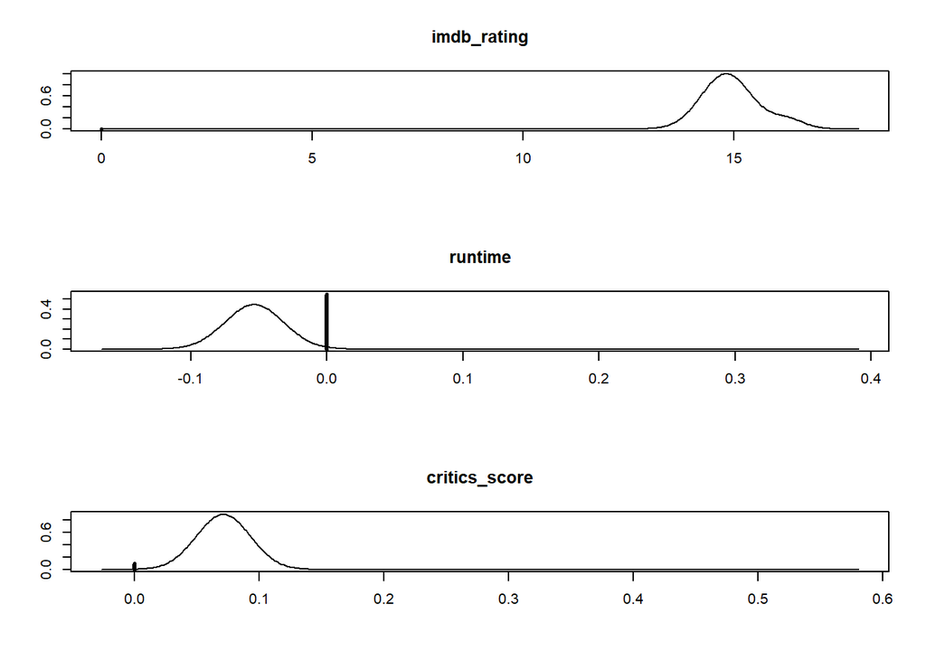

```r
coef_movie = coefficients(bma_movies)
par(mfrow = c(3,1))
plot(coef_movie, subset = c(9,4,11), ask=FALSE)
```

```r
confint(coef_movie)
```

```
##                              2.5%        97.5%          beta
## Intercept            6.155888e+01 6.309046e+01  6.234769e+01
## feature_filmyes     -1.161046e+00 6.604974e-02 -9.976793e-02
## dramayes             0.000000e+00 0.000000e+00  1.556210e-02
## runtime             -8.094911e-02 0.000000e+00 -2.386612e-02
## mpaa_rating_Ryes    -2.165468e+00 0.000000e+00 -3.053911e-01
## thtr_rel_year       -5.752620e-02 0.000000e+00 -4.482697e-03
## oscar_seasonyes     -9.891791e-01 0.000000e+00 -8.041443e-02
## summer_seasonyes     0.000000e+00 0.000000e+00  1.374639e-02
## imdb_rating          1.368518e+01 1.653992e+01  1.496854e+01
## imdb_num_votes      -2.784180e-07 2.543838e-06  2.228700e-07
## critics_score        0.000000e+00 1.054437e-01  6.398259e-02
## best_pic_winyes      0.000000e+00 0.000000e+00  1.056449e-02
## best_actor_winyes   -2.587211e+00 0.000000e+00 -2.820467e-01
## best_actress_winyes -2.723079e+00 0.000000e+00 -2.898194e-01
## best_dir_winyes     -1.353244e+00 0.000000e+00 -1.174906e-01
## top200_boxyes        0.000000e+00 0.000000e+00  8.706929e-02
## attr(,"Probability")
## [1] 0.95
## attr(,"class")
## [1] "confint.bas"
```

After reaching an acceptable model, it is now time to perform model diagnostics. The summary table of the included variables shows that the following variables can be beneficial to be included in the model :`runtime, mpaa_rating_R, imdb_rating, critics_score, best_actor_win`. Numerical variables need to be checked for normality and linearity to assure that the model is accurate.

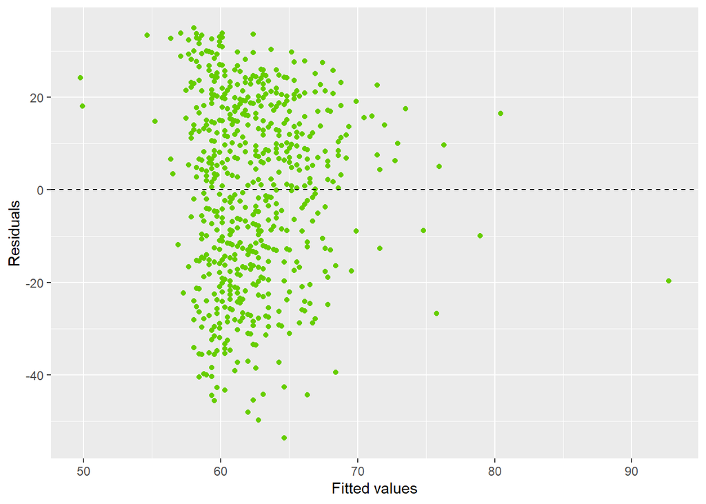

```r
audience_runtime<-lm(data=new_movies, audience_score~runtime)
ggplot(data = audience_runtime, aes(x = .fitted, y = .resid)) +
  geom_point(color = 'chartreuse3') +
  geom_hline(yintercept = 0, linetype = "dashed") +
  xlab("Fitted values") +
  ylab("Residuals")
```

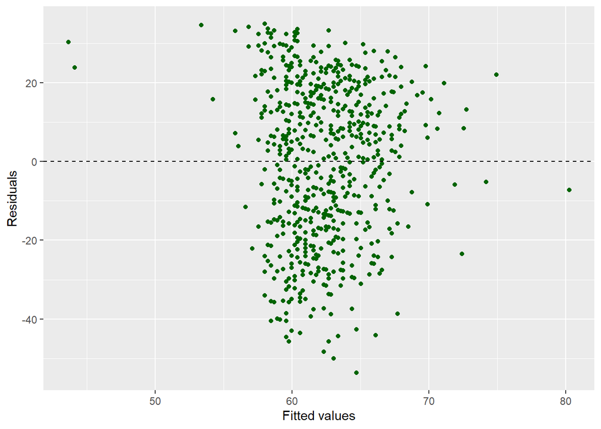

```r
new_movies<- new_movies%>%mutate(log_runtime = log(runtime))
audience_logrun<-lm(data=new_movies, audience_score~log_runtime)
ggplot(data = audience_logrun, aes(x = .fitted, y = .resid)) +
  geom_point(color = 'darkgreen') +
  geom_hline(yintercept = 0, linetype = "dashed") +
  xlab("Fitted values") +
  ylab("Residuals")
```

Although the result still demonstrates no complete linearity, we can see improvement. Let’s continue to see if other conditions hold.

**Nearly Normal Residual**

First we check the histogram of the residuals:

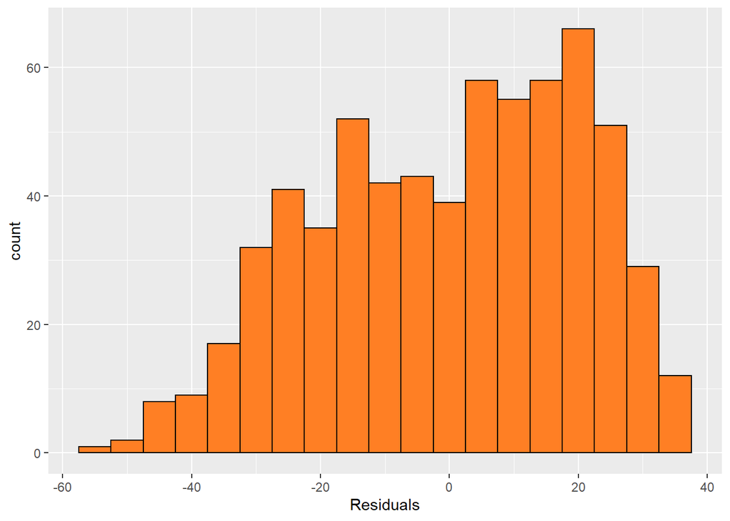

```r
ggplot(data = audience_logrun, aes(x = .resid)) +
  geom_histogram(binwidth = 5, fill = 'chocolate1', color = 'black' ) +
  xlab("Residuals")
```

We can hardly say that the residuals are normally distributed around 0. Let’s take a look at quantile-quantile (qq) plot.

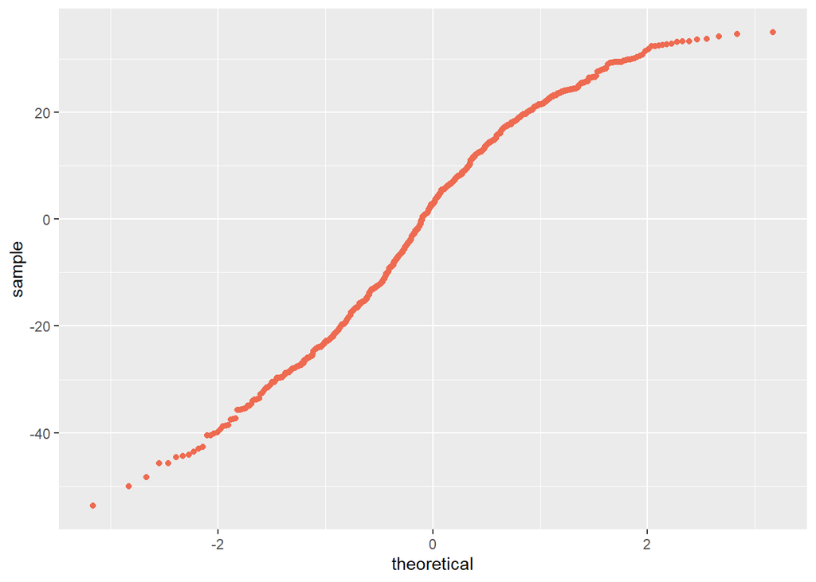

```r
ggplot(data = audience_logrun, aes(sample = .resid)) +
  stat_qq(color = 'coral2')
```

[figure not shown]

```r
ggplot(new_movies, aes(x=log_runtime, y=audience_score))+geom_jitter(color='goldenrod4')+
  labs(x="runtime", y="IMDB Rating",
       title = 'Scatter Plot of IMDB Rating vs Runtime')+
  stat_smooth(method = "lm", se = TRUE)
```

The qq plot is also curved, which means it is not normal. #### 4.2.2. `audience_score vs imdb_rating`

**Linearity** Let’s check if `audiece score` is changing linearly with `imdb_rating`. We can check that by seeing how the residuals vary with the fitted value. If they show a random scatter around zero with equal variance, we can say that the data is normal. Let’s look at the following figure.

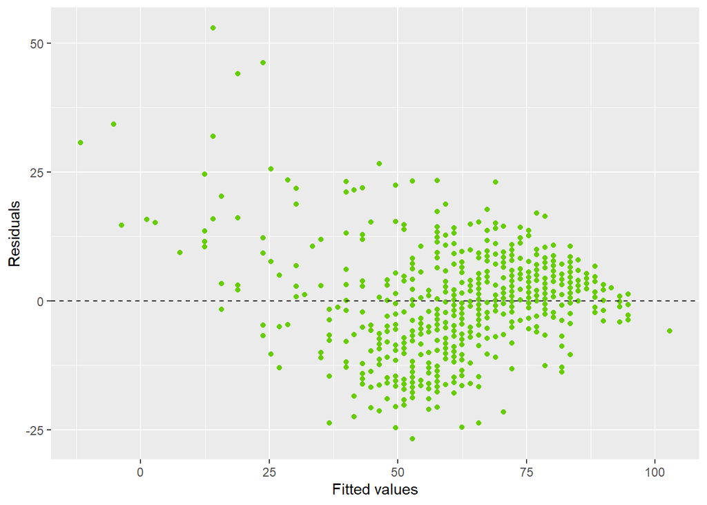

```r
audience_imdb<-lm(data=new_movies, audience_score~imdb_rating)
ggplot(data = audience_imdb, aes(x = .fitted, y = .resid)) +
  geom_point(color = 'chartreuse3') +
  geom_hline(yintercept = 0, linetype = "dashed") +
  xlab("Fitted values") +
  ylab("Residuals")
```

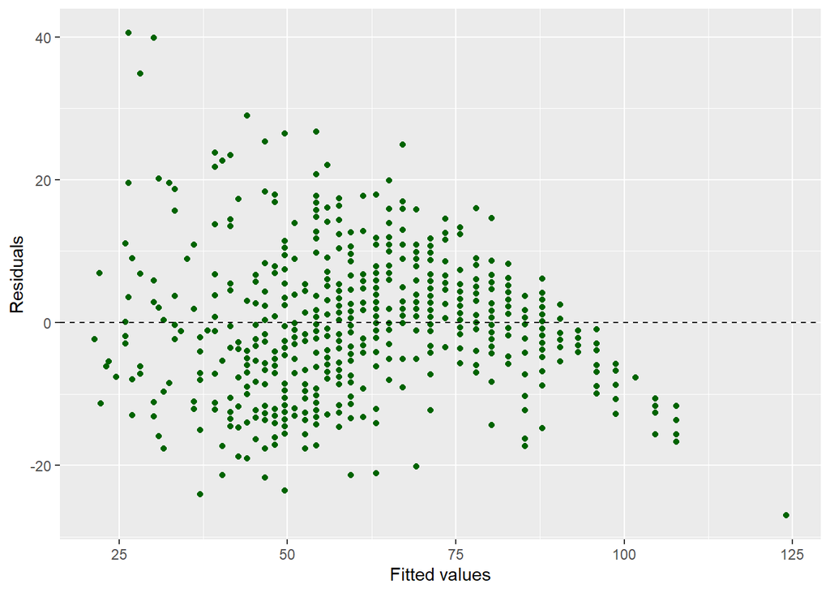

```r
new_movies<- new_movies%>%mutate(log_imdb = (imdb_rating)**3)
audience_imdbrun<-lm(data=new_movies, audience_score~log_imdb)
ggplot(data = audience_imdbrun, aes(x = .fitted, y = .resid)) +
  geom_point(color = 'darkgreen') +
  geom_hline(yintercept = 0, linetype = "dashed") +
  xlab("Fitted values") +
  ylab("Residuals")
```

Although the results are a bit more linear, we still need to check the normality. **Nearly Normal Residual**

First we check the histogram of the residuals:

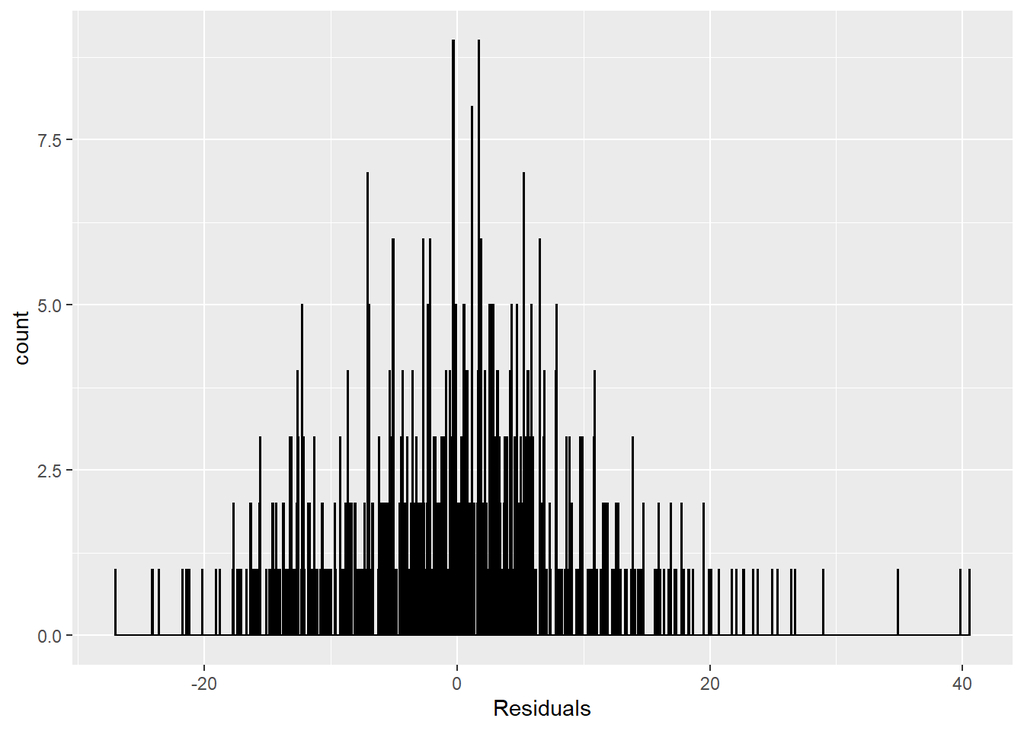

```r
ggplot(data = audience_imdbrun, aes(x = .resid)) +
  geom_histogram(binwidth = .07, fill = 'chocolate1', color = 'black' ) +
  xlab("Residuals")
```

We can easily say that the residuals are normally distributed around 0. Let’s take a look at quantile-quantile (qq) plot.

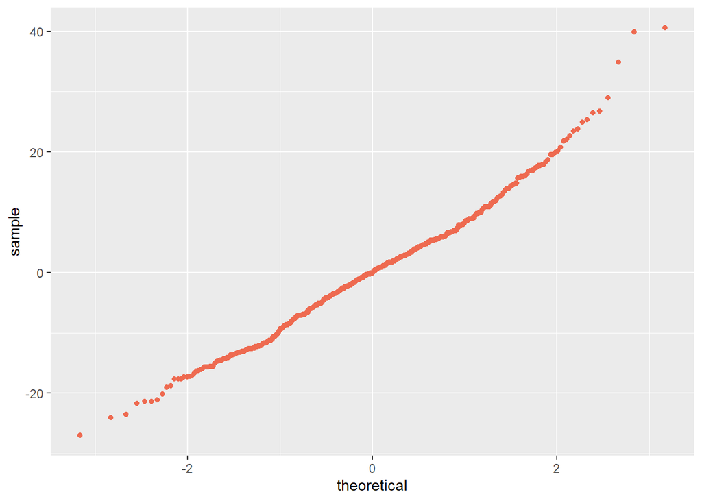

```r
ggplot(data = audience_imdbrun, aes(sample = .resid)) +
  stat_qq(color = 'coral2')
```

qqplot is also almost linear.We can say that data is linear.

[figure not shown]

```r
ggplot(new_movies, aes(x=(log_imdb), y=audience_score))+geom_jitter(color='goldenrod4')+
  labs(x="runtime", y="IMDB Rating",
       title = 'Scatter Plot of IMDB Rating vs Runtime')+
  stat_smooth(method = "lm", se = TRUE)
```

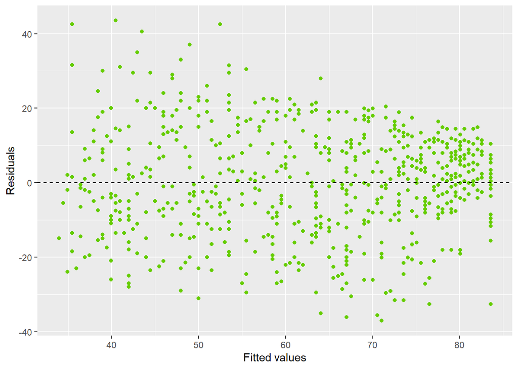

```r
audience_critics<-lm(data=new_movies, audience_score~critics_score)
ggplot(data = audience_critics, aes(x = .fitted, y = .resid)) +
  geom_point(color = 'chartreuse3') +
  geom_hline(yintercept = 0, linetype = "dashed") +
  xlab("Fitted values") +
  ylab("Residuals")
```

First we check the histogram of the residuals:

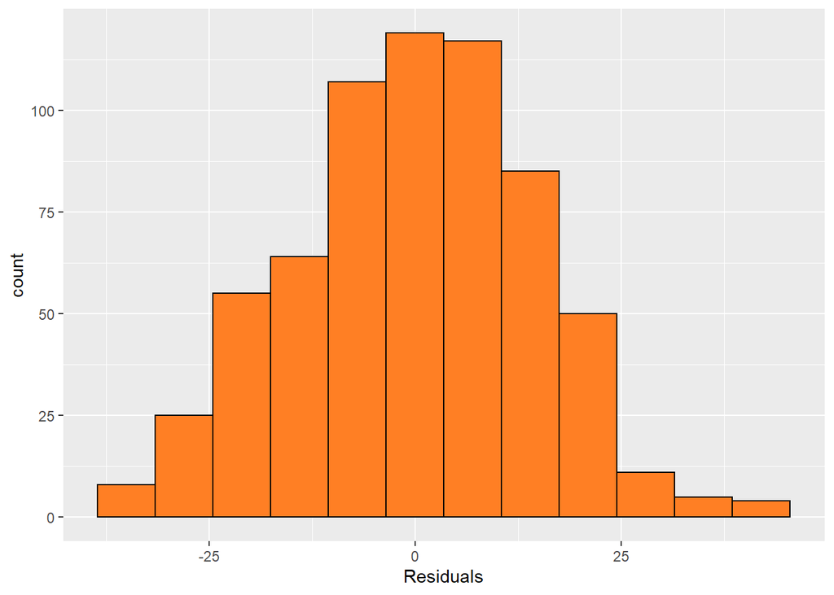

```r
ggplot(data = audience_critics, aes(x = .resid)) +
  geom_histogram(binwidth = 7, fill = 'chocolate1', color = 'black' ) +
  xlab("Residuals")
```

We can easily say that the residuals are normally distributed around 0. Let’s take a look at quantile-quantile (qq) plot.

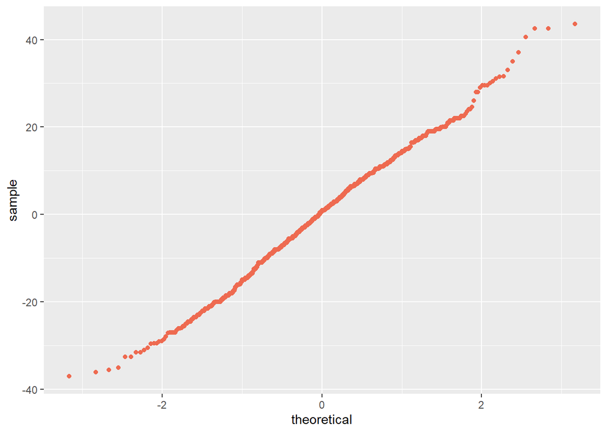

```r
ggplot(data = audience_critics, aes(sample = .resid)) +
  stat_qq(color = 'coral2')
```

[figure not shown]

```r
ggplot(new_movies, aes(x=critics_score, y=audience_score))+geom_jitter(color='goldenrod4')+
  labs(x="runtime", y="IMDB Rating",
       title = 'Scatter Plot of IMDB Rating vs Runtime')+
  stat_smooth(method = "lm", se = TRUE)
```

So we end up using these features from the main data set.

```r
final_dataset <-new_movies%>%dplyr::select( mpaa_rating_R, log_imdb, critics_score, best_actor_win, audience_score)
```

## Part 5: Prediction

Let’s predict the audience score for the movie “Deadpool”

```r
model_movies_final <- lm(audience_score ~ ., data =final_dataset)
new_movie <- data.frame(mpaa_rating_R = 'yes', log_imdb=512, critics_score= 65, best_actor_win = 'no')
predict(model_movies_final, new_movie, interval = "prediction", level = 0.95)
```

```
##        fit      lwr      upr
## 1 91.89328 73.39586 110.3907
```

```r
summary(model_movies_final)
```

```
##
## Call:
## lm(formula = audience_score ~ ., data = final_dataset)
##
## Residuals:
##     Min      1Q  Median      3Q     Max
## -24.404  -6.279  -0.127   5.381  41.209
##
## Coefficients:
##                    Estimate Std. Error t value Pr(>|t|)
## (Intercept)       20.768140   1.018641  20.388   <2e-16 ***
## mpaa_rating_Ryes  -0.955042   0.734712  -1.300   0.1941
## log_imdb           0.135665   0.004568  29.697   <2e-16 ***
## critics_score      0.040302   0.020233   1.992   0.0468 *
## best_actor_winyes -2.245235   1.051095  -2.136   0.0330 *
## ---
## Signif. codes:  0 '***' 0.001 '**' 0.01 '*' 0.05 '.' 0.1 ' ' 1
##
## Residual standard error: 9.363 on 645 degrees of freedom
## Multiple R-squared:  0.7872, Adjusted R-squared:  0.7859
## F-statistic: 596.5 on 4 and 645 DF,  p-value: < 2.2e-16
```

The audience score is 85 which lies within the predicted values.

```r
data.gprior =  bas.lm(audience_score ~ ., data=final_dataset, alpha=13, prior="g-prior")
new_movie <- data.frame(mpaa_rating_R = 'yes', log_imdb=512, critics_score= 65, best_actor_win = 'no')
data.BMA = predict(data.gprior, newdata=new_movie, estimator="BMA", se.fit=TRUE, prediction=FALSE)
confint(data.BMA)
```

```
##          2.5%    97.5%     pred
## [1,] 69.81163 111.4969 90.23267
## attr(,"Probability")
## [1] 0.95
## attr(,"class")
## [1] "confint.bas"
```